# Microbial analysis

### 0.4.1 Make the plot for field samples

First at Phylum level

```r
#D1 taxonomic level
glomD1<- tax_glom(physeqPra, "D1")
#subset to include only samples from the Red Soil project and leave out those collected from pumice stones
psDNA_RS<- subset_samples(glomD1, LandUse == "R" | LandUse == "U")

#Before merging the samples into different groups of aggregation it is essential to transform the variables to factors and then numeric, otherwise the function is not going to work. We can see that the variables are characters

str(sample_data(psDNA_RS))
```

```
## 'data.frame':    292 obs. of  8 variables:
## Formal class 'sample_data' [package "phyloseq"] with 4 slots
##   ..@ .Data    :List of 8
##   .. ..$ : chr  "R1C-2020-09-17-1" "R1C-2020-10-01-49" "R1C-2020-10-15-51" "R1C-2020-10-29-66" ...
##   .. ..$ : chr  "R1C" "R1C" "R1C" "R1C" ...
##   .. ..$ : chr  "2020-09-17" "2020-10-01" "2020-10-15" "2020-10-29" ...
##   .. ..$ : chr  "R" "R" "R" "R" ...
##   .. ..$ : chr  "1" "1" "1" "1" ...
##   .. ..$ : chr  "C" "C" "C" "C" ...
##   .. ..$ : chr  "09" "10" "10" "10" ...
##   .. ..$ : chr  "R1" "R1" "R1" "R1" ...
##   ..@ names    : chr  "Sample.ID" "SS" "date" "LandUse" ...
##   ..@ row.names: chr  "R1C-2020-09-17-1" "R1C-2020-10-01-49" "R1C-2020-10-15-51" "R1C-2020-10-29-66" ...
##   ..@ .S3Class : chr "data.frame"
```

```r
df <- as.data.frame(lapply(sample_data(psDNA_RS),function (y) if(class(y)!="factor") as.factor(y) else y),stringsAsFactors=T)
row.names(df) <- sample_names(psDNA_RS)
sample_data(psDNA_RS) <- sample_data(df)

#Now most of the variables are factors
str(sample_data(psDNA_RS))
```

```
## 'data.frame':    292 obs. of  8 variables:
## Formal class 'sample_data' [package "phyloseq"] with 4 slots
##   ..@ .Data    :List of 8
##   .. ..$ : Factor w/ 292 levels "R1C-01-04-2021",..: 14 15 16 17 18 19 20 39 40 41 ...
##   .. ..$ : Factor w/ 12 levels "R1C","R1N","R1S",..: 1 1 1 1 1 1 1 2 2 2 ...
##   .. ..$ : Factor w/ 25 levels "2020-09-17","2020-10-01",..: 1 2 3 4 5 7 8 1 2 4 ...
##   .. ..$ : Factor w/ 2 levels "R","U": 1 1 1 1 1 1 1 1 1 1 ...
##   .. ..$ : Factor w/ 2 levels "1","2": 1 1 1 1 1 1 1 1 1 1 ...
##   .. ..$ : Factor w/ 3 levels "C","N","S": 1 1 1 1 1 1 1 2 2 2 ...
##   .. ..$ : Factor w/ 12 levels "01","02","03",..: 9 10 10 10 11 12 12 9 10 10 ...
##   .. ..$ : Factor w/ 4 levels "R1","R2","U1",..: 1 1 1 1 1 1 1 1 1 1 ...
##   ..@ names    : chr  "Sample.ID" "SS" "date" "LandUse" ...
##   ..@ row.names: chr  "R1C-2020-09-17-1" "R1C-2020-10-01-49" "R1C-2020-10-15-51" "R1C-2020-10-29-66" ...
##   ..@ .S3Class : chr "data.frame"
```

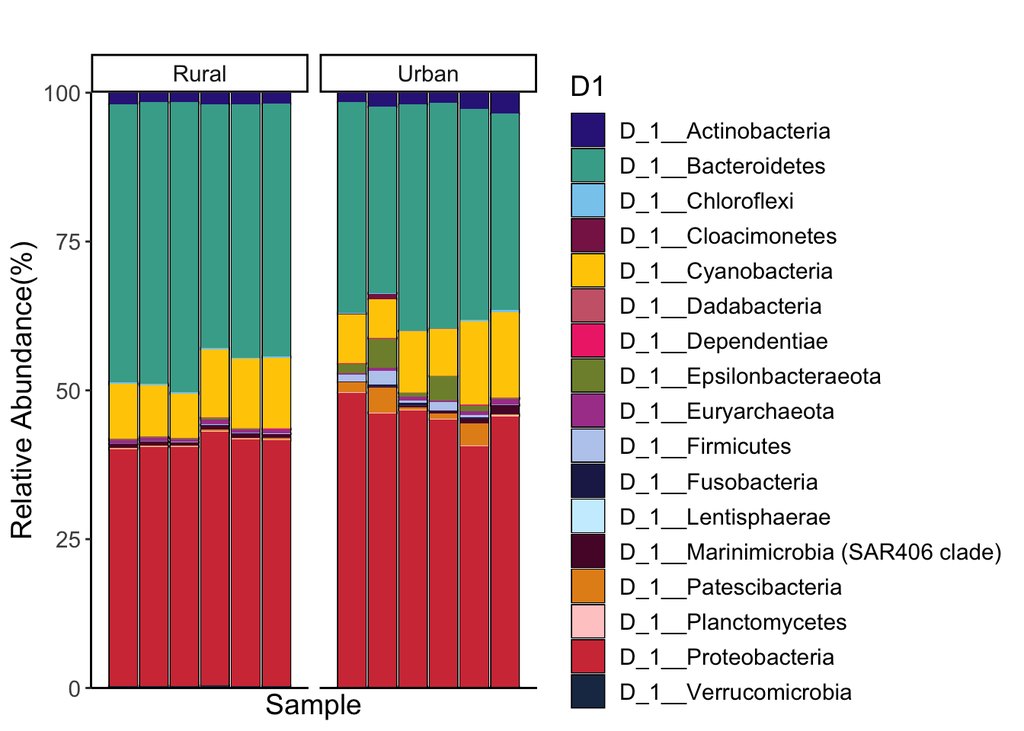

```r
psDNA_RS<-merge_samples(psDNA_RS,"SS")
psDNA_RS<- transform_sample_counts(psDNA_RS, function(OTU) 100* OTU/sum(OTU))

colours= c("#332288", "#44AA99", "#88CCEE", "#882255", "#FFCC00", "#CC6677", "#EE3377", "#7F8E39", "#AA4499", "#BBCCEE", "#222255", "#CCEEFF", "#570D32", "#E48F1B", "#FFCCCC","#D33B44","#1d3554")

#other cool colors("#999933","#DFE07C","#DDAA33","#DDCC77","#CC3311")

#labels for SS (during merging everything was changed)
SSnames<- c("R1_C", "R1_N", "R1_S", "R2_C", "R2_N", "R2_S","U1_C", "U1_N", "U1_S", "U2_C", "U2_N", "U2_S")
#labels for LandUse
LandUselab<- list("1"="Rural", "2"="Urban")
LandUselab_labeller <- function(variable,value){
  return(LandUselab[value])
}

generalbarplotD1<-plot_bar(psDNA_RS, x= "SS", fill = "D1",facet_grid= ~LandUse) +
  scale_y_continuous(expand = c(0, 0)) +
  ggtitle("") +
  scale_fill_manual(values=colours ) +
  scale_x_discrete(labels=SSnames)+
  theme(legend.title=element_blank()) +
  geom_bar(aes(fill=D1), stat="identity", position="stack", width =0.9) +
  theme_classic() +
  theme(text = element_text(size=14))+
  theme(axis.text.x = element_text(angle = 90)) +
  facet_grid(~LandUse,scales="free", labeller = LandUselab_labeller) +
  xlab("Sample") +ylab("Relative Abundance(%)") +
  theme(text = element_text(size=14))
generalbarplotD1
```

It is clear that some phylla like Epsilonbacteraerota, Firmicutes, Patescibacteria are more present in urban areas than rural ones but it is this tendency the same trough the whole year?

Here the plots with all the data separated in two plots: rural and urban

```r
#filter only data from Rural sites
psDNA_rural<- subset_samples(glomD1, LandUse == "R")


str(sample_data(psDNA_rural))
```

```
## 'data.frame':    146 obs. of  8 variables:
## Formal class 'sample_data' [package "phyloseq"] with 4 slots
##   ..@ .Data    :List of 8
##   .. ..$ : chr  "R1C-2020-09-17-1" "R1C-2020-10-01-49" "R1C-2020-10-15-51" "R1C-2020-10-29-66" ...
##   .. ..$ : chr  "R1C" "R1C" "R1C" "R1C" ...
##   .. ..$ : chr  "2020-09-17" "2020-10-01" "2020-10-15" "2020-10-29" ...
##   .. ..$ : chr  "R" "R" "R" "R" ...
##   .. ..$ : chr  "1" "1" "1" "1" ...
##   .. ..$ : chr  "C" "C" "C" "C" ...
##   .. ..$ : chr  "09" "10" "10" "10" ...
##   .. ..$ : chr  "R1" "R1" "R1" "R1" ...
##   ..@ names    : chr  "Sample.ID" "SS" "date" "LandUse" ...
##   ..@ row.names: chr  "R1C-2020-09-17-1" "R1C-2020-10-01-49" "R1C-2020-10-15-51" "R1C-2020-10-29-66" ...
##   ..@ .S3Class : chr "data.frame"
```

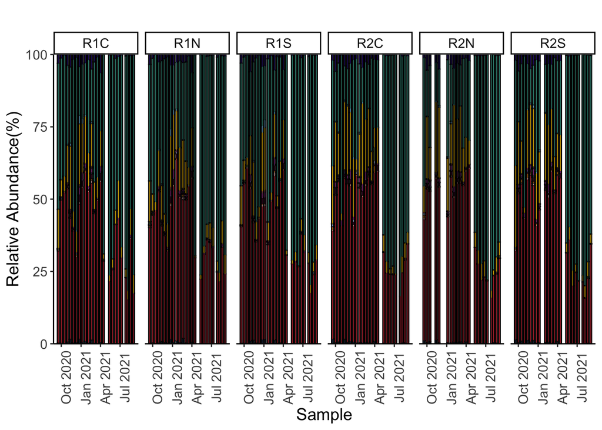

```r
df <- as.data.frame(lapply(sample_data(psDNA_rural),function (y) if(class(y)!="factor") as.factor(y) else y),stringsAsFactors=T)
df$date<- ymd(df$date)
row.names(df) <- sample_names(psDNA_rural)
sample_data(psDNA_rural) <- sample_data(df)


colours= c("#332288", "#44AA99", "#88CCEE", "#882255", "#FFCC00", "#CC6677", "#EE3377", "#7F8E39", "#AA4499", "#BBCCEE", "#222255", "#CCEEFF", "#570D32", "#E48F1B", "#FFCCCC","#D33B44","#1d3554")

montlybarruralD1<-plot_bar(psDNA_rural, x= "date", fill = "D1",facet_grid= ~SS) +
  scale_y_continuous(expand = c(0, 0)) +
  ggtitle("") +
  scale_fill_manual(values=colours ) +
  #scale_x_discrete(labels=date)+
  theme(legend.title=element_blank()) +
  geom_bar(aes(fill=D1), stat="identity", position="stack", width =1) +
  theme_classic() +
  theme(text = element_text(size=12))+
  theme(axis.text.x = element_text(angle = 90)) +
  facet_grid(~SS,scales="free") +
  xlab("Sample") +ylab("Relative Abundance(%)") +
  theme(text = element_text(size=14))

montlybarruralD1 + theme(legend.position="none")
```

```r
#filter only data from Urban sites
psDNA_urban<- subset_samples(glomD1, LandUse == "U")

str(sample_data(psDNA_urban))
```

```
## 'data.frame':    146 obs. of  8 variables:
## Formal class 'sample_data' [package "phyloseq"] with 4 slots
##   ..@ .Data    :List of 8
##   .. ..$ : chr  "U1C-2020-09-17-85" "U1C-2020-10-01-3" "U1C-2020-10-15-29" "U1C-2020-10-29-55" ...
##   .. ..$ : chr  "U1C" "U1C" "U1C" "U1C" ...
##   .. ..$ : chr  "2020-09-17" "2020-10-01" "2020-10-15" "2020-10-29" ...
##   .. ..$ : chr  "U" "U" "U" "U" ...
##   .. ..$ : chr  "1" "1" "1" "1" ...
##   .. ..$ : chr  "C" "C" "C" "C" ...
##   .. ..$ : chr  "09" "10" "10" "10" ...
##   .. ..$ : chr  "U1" "U1" "U1" "U1" ...
##   ..@ names    : chr  "Sample.ID" "SS" "date" "LandUse" ...
##   ..@ row.names: chr  "U1C-2020-09-17-85" "U1C-2020-10-01-3" "U1C-2020-10-15-29" "U1C-2020-10-29-55" ...
##   ..@ .S3Class : chr "data.frame"
```

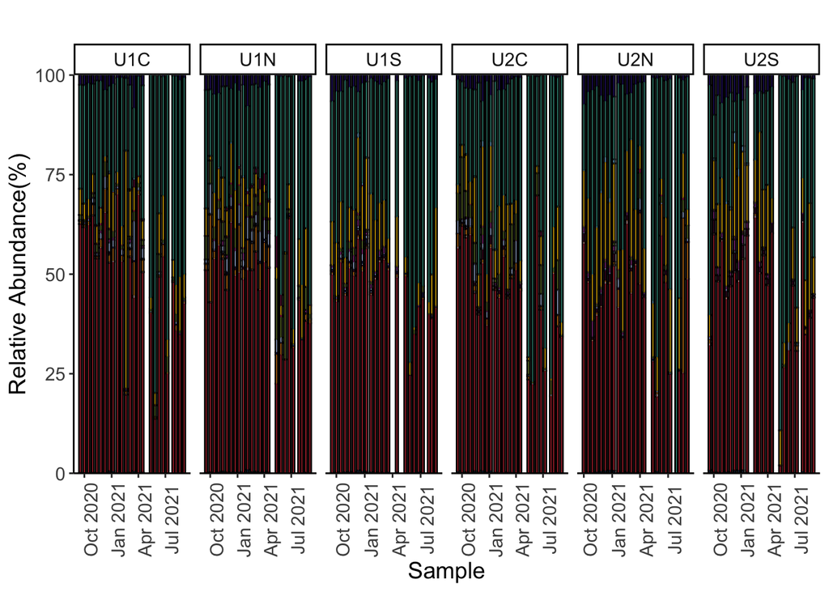

```r
df <- as.data.frame(lapply(sample_data(psDNA_urban),function (y) if(class(y)!="factor") as.factor(y) else y),stringsAsFactors=T)
df$date<- ymd(df$date)
row.names(df) <- sample_names(psDNA_urban)
sample_data(psDNA_urban) <- sample_data(df)

colours= c("#332288", "#44AA99", "#88CCEE", "#882255", "#FFCC00", "#CC6677", "#EE3377", "#7F8E39", "#AA4499", "#BBCCEE", "#222255", "#CCEEFF", "#570D32", "#E48F1B", "#FFCCCC","#D33B44","#1d3554")

montlybarurbanD1<-plot_bar(psDNA_urban, x= "date", fill = "D1",facet_grid= ~SS) +
  scale_y_continuous(expand = c(0, 0)) +
  ggtitle("") +
  scale_fill_manual(values=colours ) +
  #scale_x_discrete(labels=date)+
  theme(legend.title=element_blank()) +
  geom_bar(aes(fill=D1), stat="identity", position="stack", width =1) +
  theme_classic() +
  theme(text = element_text(size=12))+
  theme(axis.text.x = element_text(angle = 90)) +
  facet_grid(~SS,scales="free") +
  xlab("Sample") +ylab("Relative Abundance(%)") +
  theme(text = element_text(size=14))


montlybarurbanD1+ theme(legend.position="none")
```

Let’s check for different months:

```r
#We need to repeat some steps from before so I'll skip the explanations. We just need to change the number when subsetting the month so we can get a plot from each month. Here an example for december:
psDNA_month<- subset_samples(glomD1, Month == "12")

df <- as.data.frame(lapply(sample_data(psDNA_month),function (y) if(class(y)!="factor") as.factor(y) else y),stringsAsFactors=T)
row.names(df) <- sample_names(psDNA_month)
sample_data(psDNA_month) <- sample_data(df)

str(sample_data(psDNA_month))
```

```
## 'data.frame':    22 obs. of  8 variables:
## Formal class 'sample_data' [package "phyloseq"] with 4 slots
##   ..@ .Data    :List of 8
##   .. ..$ : Factor w/ 22 levels "R1C-2020-12-10-20",..: 1 2 3 4 6 9 12 13 14 15 ...
##   .. ..$ : Factor w/ 11 levels "R1C","R1N","R1S",..: 1 1 2 2 3 5 6 7 7 8 ...
##   .. ..$ : Factor w/ 2 levels "2020-12-10","2020-12-24": 1 2 1 2 2 1 2 1 2 1 ...
##   .. ..$ : Factor w/ 2 levels "R","U": 1 1 1 1 1 1 2 2 2 2 ...
##   .. ..$ : Factor w/ 2 levels "1","2": 1 1 1 1 1 2 1 1 1 1 ...
##   .. ..$ : Factor w/ 3 levels "C","N","S": 1 1 2 2 3 3 1 2 2 3 ...
##   .. ..$ : Factor w/ 1 level "12": 1 1 1 1 1 1 1 1 1 1 ...
##   .. ..$ : Factor w/ 4 levels "R1","R2","U1",..: 1 1 1 1 1 2 3 3 3 3 ...
##   ..@ names    : chr  "Sample.ID" "SS" "date" "LandUse" ...
##   ..@ row.names: chr  "R1C-2020-12-10-20" "R1C-2020-12-24-36" "R1N-2020-12-10-21" "R1N-2020-12-24-23" ...
##   ..@ .S3Class : chr "data.frame"
```

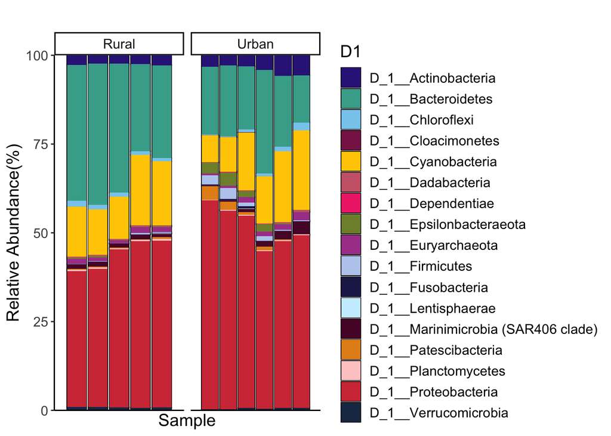

```r
psDNA_month<-merge_samples(psDNA_month,"SS")
psDNA_month<- transform_sample_counts(psDNA_month, function(OTU) 100* OTU/sum(OTU))
colours= c("#332288", "#44AA99", "#88CCEE", "#882255", "#FFCC00", "#CC6677", "#EE3377", "#7F8E39", "#AA4499", "#BBCCEE", "#222255", "#CCEEFF", "#570D32", "#E48F1B", "#FFCCCC","#D33B44","#1d3554")

#other cool colors("#999933","#DFE07C","#DDAA33","#DDCC77","#CC3311")

#labels for SS (during merging everything was changed)
SSnames<- c("R1_C", "R1_N", "R1_S", "R2_C", "R2_N", "R2_S","U1_C", "U1_N", "U1_S", "U2_C", "U2_N", "U2_S")

#labels for LandUse
LandUselab<- list("1"="Rural", "2"="Urban")
LandUselab_labeller <- function(variable,value){
  return(LandUselab[value])
}

montlybarplotD1<-plot_bar(psDNA_month, x= "SS", fill = "D1",facet_grid= ~LandUse) +
  scale_y_continuous(expand = c(0, 0)) +
  ggtitle("") +
  scale_fill_manual(values=colours ) +
  scale_x_discrete(labels=SSnames)+
  theme(legend.title=element_blank()) +
  geom_bar(aes(fill=D1), stat="identity", position="stack", width =0.9) +
  theme_classic() +
  theme(text = element_text(size=14))+
  theme(axis.text.x = element_text(angle = 90)) +
  facet_grid(~LandUse,scales="free", labeller = LandUselab_labeller) +
  xlab("Sample") +ylab("Relative Abundance(%)") +
  theme(text = element_text(size=14))
montlybarplotD1
```

## 0.5 Alpha Diversity

Richness estimate

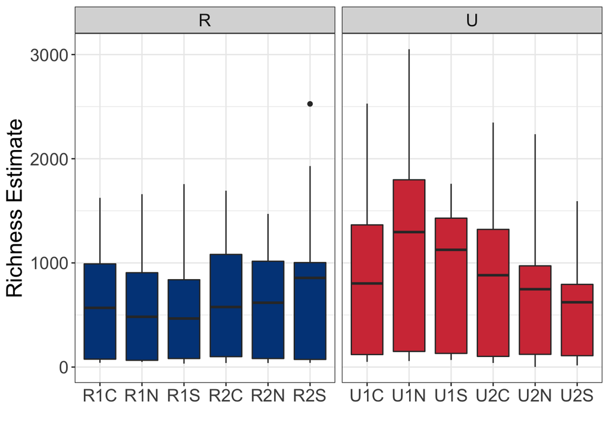

```r
alphazero<-  subset_samples(ps, LandUse == "R" | LandUse == "U")

ad <- breakaway(alphazero)

adiver<- summary(ad) %>%
  add_column("Sample.ID" = alphazero %>% otu_table %>% sample_names)

badf<- merge(adiver, metatable, by = "Sample.ID")

#just comparing sampling sites
SSAD <- ggplot(badf, aes(x=SS, y=estimate, fill = LandUse)) +  facet_grid(. ~ LandUse, scales="free" )+ geom_boxplot() + theme_bw() + theme(text = element_text(size=14)) +ylab("Richness Estimate") +xlab("") + scale_fill_manual(values=c("#004488", "#D33B44"))+ theme(text = element_text(size=18)) + theme(legend.position="none")

SSAD
```

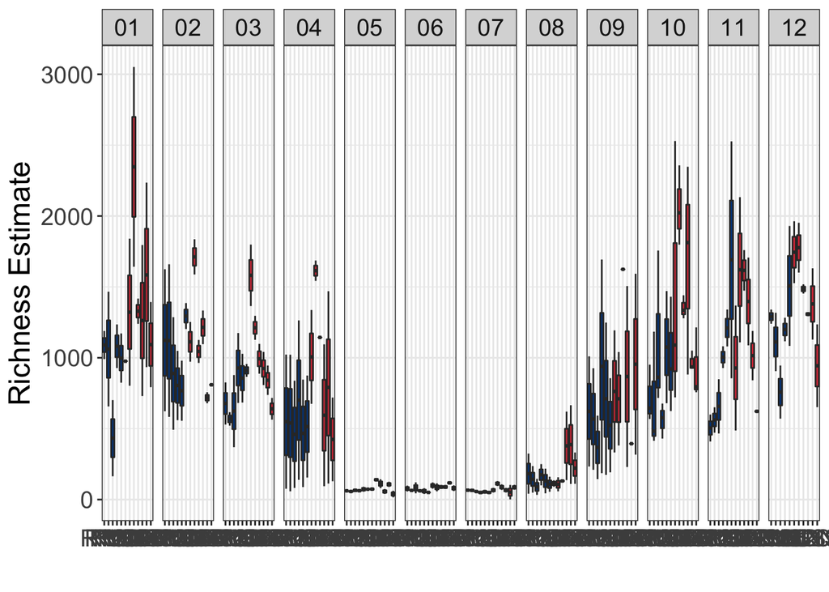

```r
LandUseAD <- ggplot(badf, aes(x=SS, y=estimate, fill = LandUse)) +  facet_grid(. ~ Month, scales="free" )+ geom_boxplot() + theme_bw() + theme(text = element_text(size=14)) +ylab("Richness Estimate") +xlab("") + scale_fill_manual(values=c("#004488", "#D33B44"))+ theme(text = element_text(size=18)) + theme(legend.position="none")

LandUseAD
```

## 0.6 Ordination and distance

We calculate the Atchison Distance

First, lets perform a log-ratio normalization:

```r
OTU4clr<- data.frame(t(data.frame(otu_table(ps))))
row.names(OTU4clr) <- gsub("\\.", "", row.names(OTU4clr))
OTUs.clr <- codaSeq.clr(OTU4clr + 0.5, samples.by.row=TRUE)
OTU2 <- otu_table(as.matrix(OTUs.clr), taxa_are_rows = FALSE)

metatable2<-metatable
row.names(metatable2) <- gsub("-", "", row.names(metatable2))
META2<- sample_data(metatable2)

psCLR <- phyloseq(OTU2,taxon,META2)
```

PCA for all the samples

```r
#remove pumice stones samples
psCLR_RS1 <-  subset_samples(psCLR, LandUse != "p" )

OTU<- data.frame(otu_table(psCLR_RS1))
metaF <- metatable2[row.names(metatable2) %in% row.names(OTU),]

adonis2(vegdist(OTU , method = "euclidean") ~ SS, data = metaF)
```

```
## Permutation test for adonis under reduced model
## Terms added sequentially (first to last)
## Permutation: free
## Number of permutations: 999
##
## adonis2(formula = vegdist(OTU, method = "euclidean") ~ SS, data = metaF)
##           Df SumOfSqs      R2      F Pr(>F)
## SS        11    93530 0.11268 3.2323  0.001 ***
## Residual 280   736546 0.88732
## Total    291   830076 1.00000
## ---
## Signif. codes:  0 '***' 0.001 '**' 0.01 '*' 0.05 '.' 0.1 ' ' 1
```

```r
adonis2(vegdist(OTU , method = "euclidean") ~ Month, data = metaF)
```

```
## Permutation test for adonis under reduced model
## Terms added sequentially (first to last)
## Permutation: free
## Number of permutations: 999
##
## adonis2(formula = vegdist(OTU, method = "euclidean") ~ Month, data = metaF)
##           Df SumOfSqs      R2      F Pr(>F)
## Month     11   165240 0.19907 6.3265  0.001 ***
## Residual 280   664836 0.80093
## Total    291   830076 1.00000
## ---
## Signif. codes:  0 '***' 0.001 '**' 0.01 '*' 0.05 '.' 0.1 ' ' 1
```

PCA for all the samples

```r
distmat<- vegdist(OTU, method = "euclidean")

PC <- princomp(distmat)
library("factoextra")
```

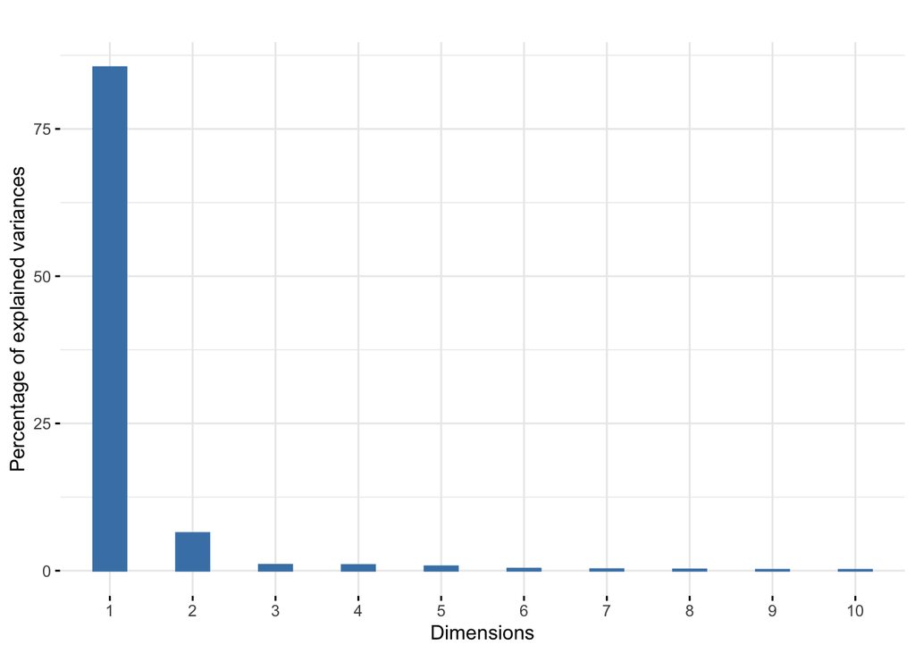

```r
fviz_eig(PC, geom = "bar", bar_width = 0.4) + ggtitle("")
```

Plot with colors indicating month

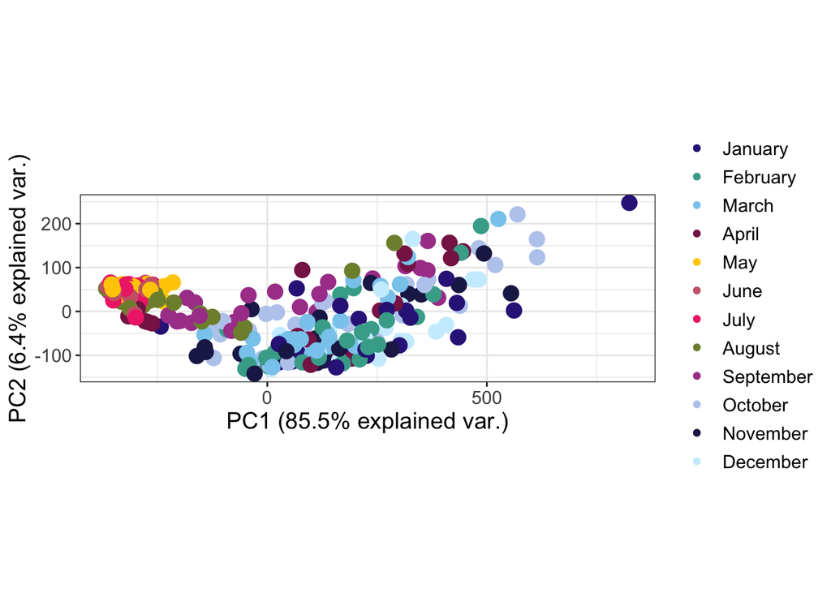

```r
metaF$id<- row.names(metaF)
metaF <- metaF[match(names(PC$scale), metaF$id),]
pMonth<-ggbiplot(PC, var.axes = FALSE, obs.scale = 1, groups = metaF$Month) +theme_bw()+scale_color_manual(labels = c("January", "February", "March", "April", "May", "June", "July", "August", "September", "October", "November", "December"), values=c("#332288", "#44AA99", "#88CCEE", "#882255", "#FFCC00", "#CC6677", "#EE3377", "#7F8E39", "#AA4499", "#BBCCEE", "#222255", "#CCEEFF"), name = "") + geom_point(aes(color=metaF$Month,size = 4))+ theme(text = element_text(size=14)) +ggtitle("") + scale_size_identity()

pMonth
```

Plot with colors indicating Area

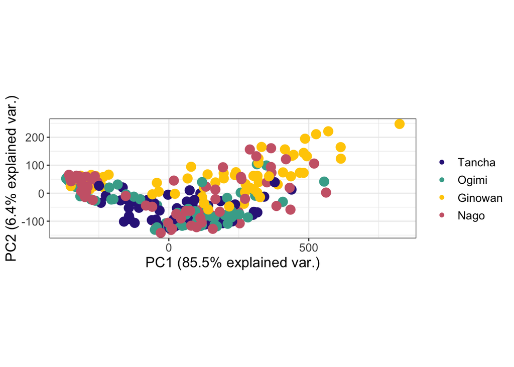

```r
metaF$id<- row.names(metaF)
metaF <- metaF[match(names(PC$scale), metaF$id),]
parea<-ggbiplot(PC, var.axes = FALSE, obs.scale = 1, groups = metaF$Area) +theme_bw()+scale_color_manual(labels = c("Tancha", "Ogimi", "Ginowan", "Nago"), values=c("#332288", "#44AA99", "#FFCC00", "#CC6677"), name = "") + geom_point(aes(color=metaF$Area,size = 4))+ theme(text = element_text(size=14)) +ggtitle("") + scale_size_identity()

parea
```

Plot with colors indicating SS

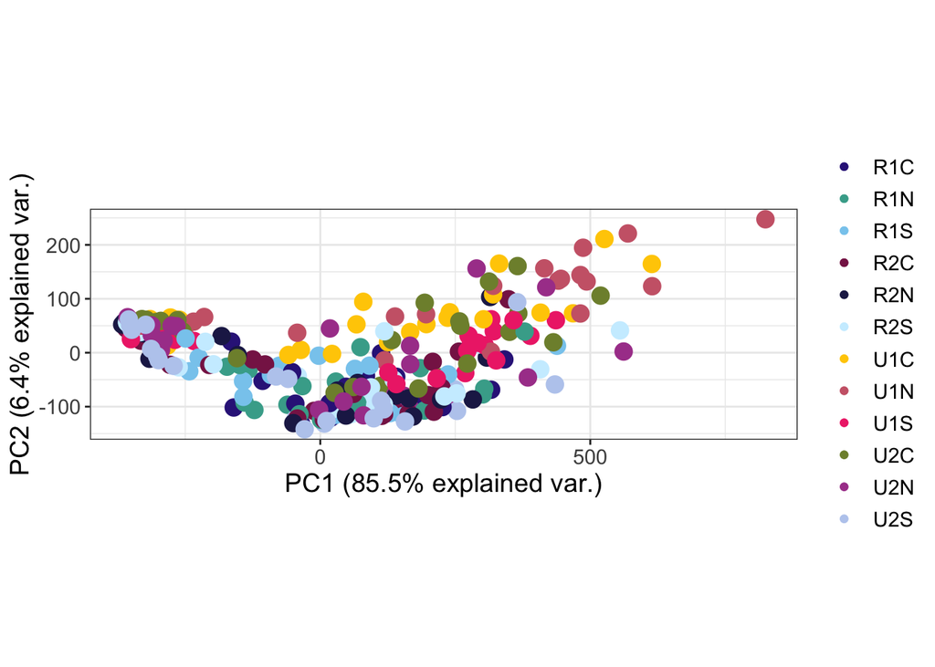

```r
metaF$id<- row.names(metaF)
metaF <- metaF[match(names(PC$scale), metaF$id),]
pSS<-ggbiplot(PC, var.axes = FALSE, obs.scale = 1, groups = metaF$SS) +theme_bw()+scale_color_manual(values=c("#332288", "#44AA99", "#88CCEE", "#882255","#222255", "#CCEEFF", "#FFCC00", "#CC6677", "#EE3377", "#7F8E39", "#AA4499", "#BBCCEE"), name = "") + geom_point(aes(color=metaF$SS,size = 4))+ theme(text = element_text(size=14)) +ggtitle("") + scale_size_identity()

pSS
```

## 0.7 Other diversity indexes

```r
#GP <- prune_species(speciesSums(ps) > 0, ps)

#plot_richness(GP, x=SS, measures = c("Chao1", "Shannon"))
```